# Loan Default Prediction for Evergreen National Bank

Group 1 Data Science Consultants

12/1/2024

## Introduction

This report outlines the development of a **Predictive Loan Default Model** for Evergreen National Bank using the PKDD’99 Berka dataset. The model leverages advanced data science techniques to:

- Identify high-risk loan applicants.
- Enhance credit risk management.
- Support operational efficiency and decision-making.

The final deliverable includes a trained machine learning model, visualizations, and actionable recommendations for proactive credit risk management.

## Objectives

1. **Proactive Risk Management**: Identify high-risk borrowers early to reduce financial losses.
2. **Decision Support**: Automate decision-making using data-driven insights.
3. **Efficiency Improvement**: Optimize resource allocation by focusing on risky segments.
4. **Customer Retention**: Provide tailored loan offerings for different borrower segments.

## Data Overview

- **Loan**: Loan details including amount, duration, and repayment status.
- **Account**: Account-level details and linkage to districts.
- **Disposition**: Links between clients and accounts.
- **Transactions**: Transaction-level details like amounts and balance.
- **District**: Demographic and geographic information.
- **Client**: Personal details of clients.
- **Order**: Recurring payment details including recipient bank, account, amount, and purpose.
- **Card**: Credit card details including type and issuance date.

By looking at the status variable in the Loan table, there are 4 distinct values: A, B, C, and D. A: Contract finished, no problems. B: Contract finished, loan not paid. C: Running contract, okay so far. D: Running contract, client in debt.

These relationships allow us to integrate data for a comprehensive analysis.

## Step 1: Research Questions and Analysis

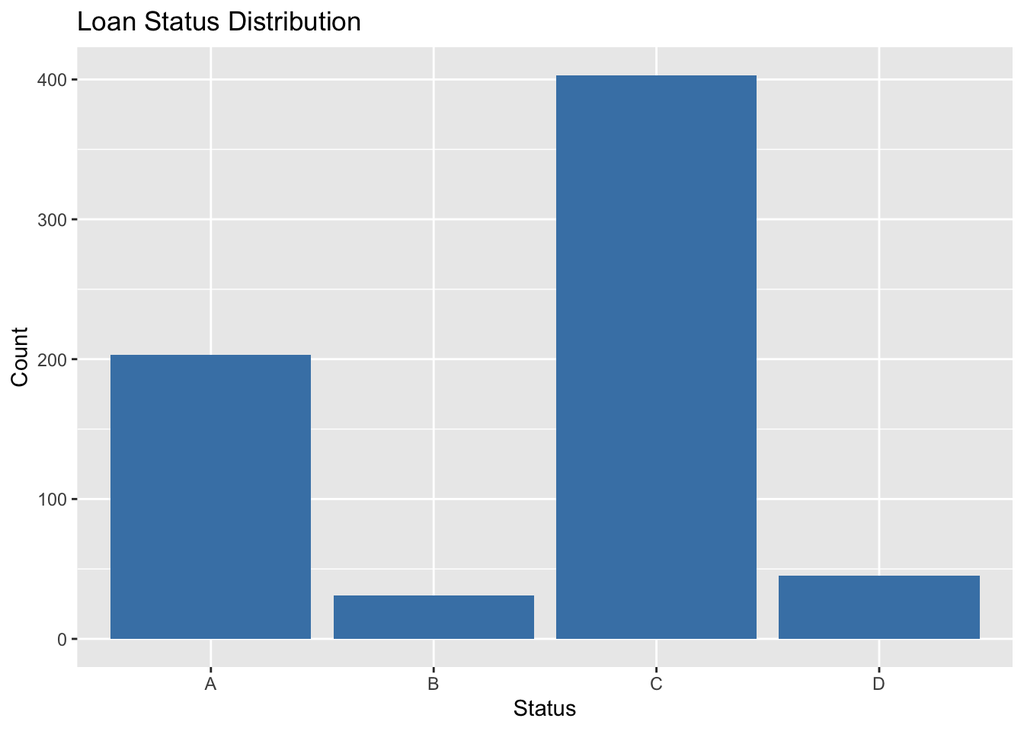

### Data Preprocessing

Prepare the dataset for analysis by cleaning, merging, and engineering relevant features. Ensure all variables are in the proper format for visualizations and modeling.

### Q1: Are larger loan amounts and longer durations associated with higher default risks?

Understanding whether larger loan amounts and longer durations increase default risks helps banks manage credit risk effectively. This insight allows for better loan structuring, risk-based pricing, and targeted interventions to minimize losses while ensuring borrowers can manage their repayment obligations.

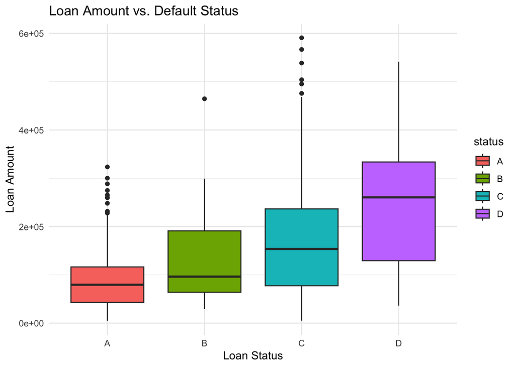

#### Observation:

Status A (Contract finished, no problems): These loans have the smallest median loan amounts, indicating borrowers with smaller loans are more likely to pay them off without issues.

Status B (Contract finished, loan not paid): Median loan amounts are slightly higher than Status A, indicating borrowers with unpaid loans at contract completion might have taken larger loans.

Status C (Running contract, okay so far): Median loan amounts are higher than Status A and B. Borrowers with ongoing contracts and no issues appear to handle moderate loan amounts effectively.

#### Conclusion:

Larger loan amounts are associated with financial difficulties (Status D: running contracts with debt).

Borrowers with smaller loans are more likely to pay off their loans successfully (Status A).

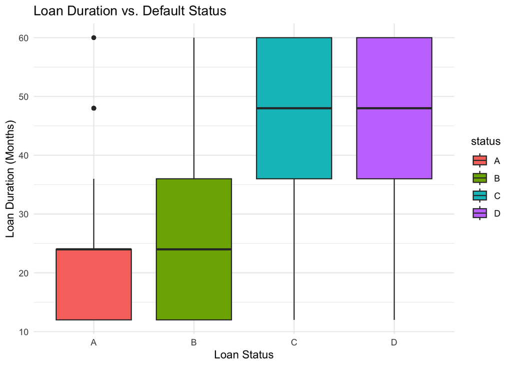

#### Observations:

Status A (Contract finished, no problems): These loans have the shortest durations, indicating borrowers with shorter loan terms are more likely to complete their contracts successfully.

Status B (Contract finished, loan not paid): Loan durations are slightly longer than Status A, indicating that longer contracts may contribute to repayment challenges.

Status C (Running contract, okay so far): Median durations are longer than Status A and B. Borrowers with ongoing contracts and no issues are managing longer-term loans effectively.

#### Conclusion:

Shorter loan durations are associated with successful repayment (Status A).

### Q2: How does a client’s account balance affect their ability to repay loans on time?

We can analyze the relationship between the average account balance and the loan status. Borrowers with lower balances are expected to struggle more with repayment, leading to higher chances of falling into debt.

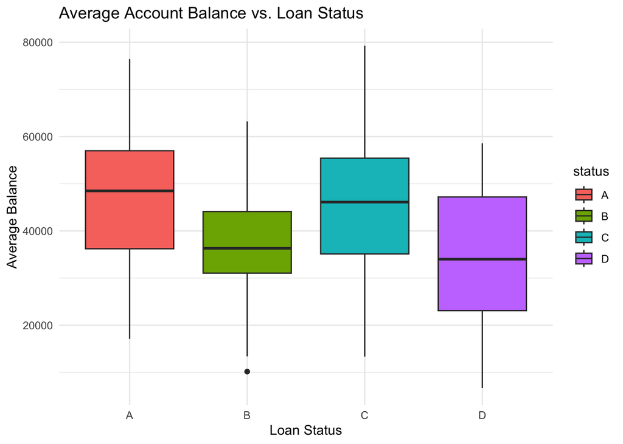

```
   status mean_balance median_balance count
   <fctr>        <num>          <num> <int>
1:      A     47295.54       48492.10   203
2:      B     35159.59       36316.49    31
3:      D     35170.94       34002.08    45
4:      C     45588.57       46116.73   403
```

#### Observations:

The boxplot shows the distribution of average account balances (avg_balance) across different loan statuses (A, B, C, and D):

Borrowers with status A (Contract finished, no problems) tend to have higher average balances compared to other statuses, indicating better financial health.

Borrowers with status B (Contract finished, loan not paid) and status D (Running contract, client in debt) exhibit significantly lower balances, implying financial struggles.

Borrowers with status C (Running contract, okay so far) have moderate average balances, which are higher than B and D but lower than A.

#### Conclusion:

A higher average account balance is correlated with better loan repayment outcomes (status A). Borrowers with low balances are more likely to miss payments or have ongoing financial difficulties (status B and D).

This suggests that account balance is a strong indicator of a borrower’s ability to meet loan repayment commitments. Financial institutions might consider incorporating account balance metrics into their credit risk assessment models to better predict loan repayment outcomes.

### Q3: Does a history of frequent overdrafts increase the likelihood of default?

We aim to analyze whether a history of frequent overdrafts serves as a reliable predictor of loan default risk, focusing on identifying patterns of financial instability. By examining the relationship between overdraft frequency and default outcomes, we seek to determine if this behavior can provide actionable insights for proactive risk assessment.

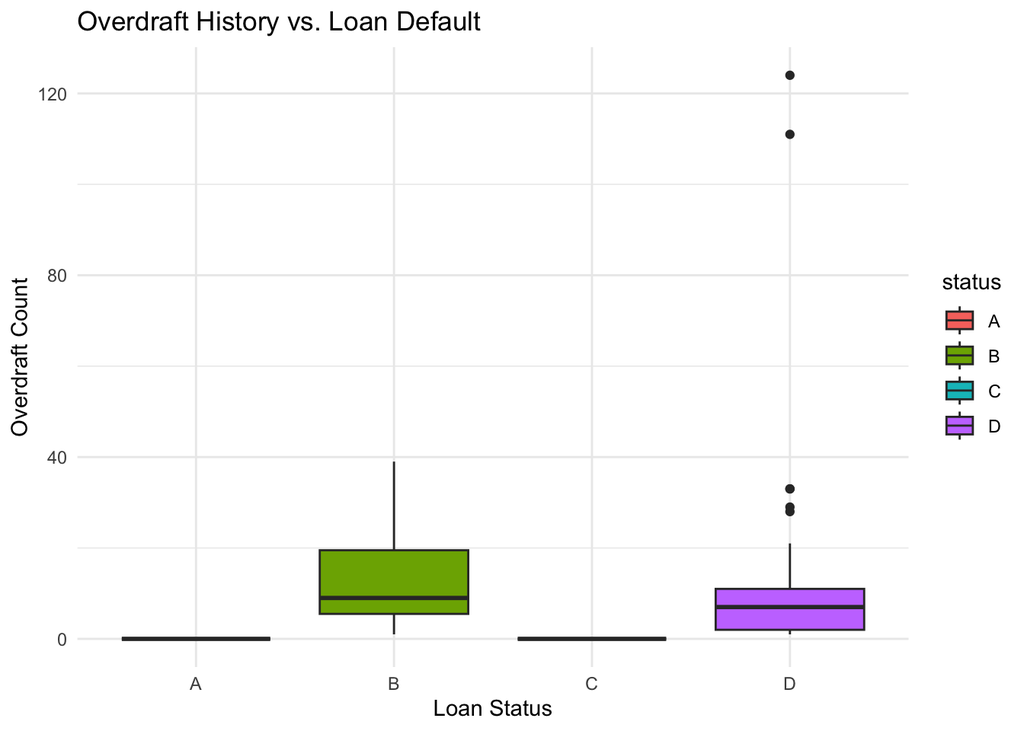

```
   status mean_overdraft median_overdraft count
   <fctr>          <num>            <num> <int>
1:      A        0.00000                0   203
2:      B       13.06452                9    31
3:      D       13.35556                7    45
4:      C        0.00000                0   403
```

#### Observations:

Status A (Contract finished, no problems): Borrowers with Status A have 0 overdraft counts. This indicates that these borrowers are financially disciplined, avoiding overdrafts entirely while managing their loans effectively.

Status C (Running contract, okay so far): Borrowers with Status C also show 0 overdraft counts, implying they maintain financial stability during the loan term and are on track with their repayments.

Status B (Contract finished, loan not paid): Borrowers with Status B have higher overdraft counts, with a median of 9 overdrafts and a mean of 13. This suggests a significant correlation between frequent overdrafts and loan repayment issues, as these borrowers failed to fully repay their loans.

Status D (Running contract, client in debt): Borrowers with Status D also show frequent overdrafts, with a median of 7 and a mean of 13.3 overdrafts. This highlights that borrowers currently struggling with debt are likely to have a history of overdrafts.

#### Conclusion:

Mean and Median Overdrafts: Borrowers in Status B and D exhibit significantly higher overdraft counts compared to Status A and C. This supports the hypothesis that overdrafts are linked to repayment difficulties and financial instability.

Count Distribution: Status C has the highest count (403), indicating that most borrowers are managing their loans well so far. In contrast, Status B and D have smaller borrower counts but higher overdraft averages, reinforcing their risk profile.

## Step 2: Feature Engineering

### Loan Table

In this part, we added a prefix to column names, converted loan_payments to Integer, formatted loan_date as a Date, and inspected the Data Frame.

```
[1] 682   7
```

### Account Table

1. **Updated `frequency` Column**:
   - Replaced values with descriptive labels: `"POPLATEK MESICNE"` → `"monthly"`, `"POPLATEK TYDNE"` → `"weekly"`, `"POPLATEK PO OBRATU"` → `"after_transaction"`.
2. **Formatted `date` Column**:
   - Converted `date` column to Date format using `%y%m%d`.
3. **Renamed and Prefixed Columns**:
   - Added `"acc_"` as a prefix to all column names in `account_df`.
   - Renamed `loan_account_id` and `acc_account_id` to `account_id` for consistency.
4. **Merged DataFrames**:
   - Performed a left join of `loan_df` and `account_df` on `account_id`.
5. **Calculated and Cleaned Columns**:
   - Created `day_before_loan` as the difference (in days) between `loan_date` and `acc_date`.
   - Removed the `acc_date` column.

```
[1] 4500    4
```

```
[1] "loan_loan_id"    "loan_account_id" "loan_date"       "loan_amount"
[5] "loan_duration"   "loan_payments"   "loan_status"
```

```
[1] "acc_account_id"  "acc_district_id" "acc_frequency"   "acc_date"
```

```
[1] 682  10
```

### Manipulating k_symbol and joining Transaction table

1. **Replaced Empty Strings**: Converted empty or space-filled values in `k_symbol` and `operation` columns to `NA`.
2. **Updated Columns with Descriptive Labels**:
   - `type`: Mapped “PRIJEM” to “credit” and “VYDAJ/VYBER” to “withdrawal”.
   - `k_symbol`: Translated values (e.g., “POJISTNE” → “insurance”, “UVER” → “loan”).
   - `operation`: Mapped actions (e.g., “VYBER KARTOU” → “credit_card_withdrawal”).
3. **Formatted `date` Column**: Converted `date` to Date format (`%y%m%d`).
4. **Checked Date Range**: Identified min and max dates in the dataset.

```
         type      n
       <char>  <int>
1:     credit 405083
2: withdrawal 651237
```

```
                     operation      n
                        <char>  <int>
1: collection_from_anotherbank  65226
2:      credit_card_withdrawal   8036
3:              credit_in_cash 156743
4:   remittance_to_anotherbank 208283
5:          withdrawal_in_cash 434918
6:                        <NA> 183114
```

```
                    k_symbol      n
                      <char>  <int>
1:                 household 118065
2:                 insurance  18500
3:         interest_credited 183114
4:                      loan  13580
5:           old-age_pension  30338
6:     payment_for_statement 155832
7: sanction_interest_neg_bal   1577
8:                      <NA> 535314
```

```
    min_date   max_date
1 1993-01-01 1998-12-31
```

#### Creating Money in & Money out

1. **Copied the Original Data**: Created a backup of `trans_df` as `trans_df_in`.
2. **Defined a Helper Function**:
   - Created `money_in_out` to segregate transaction amounts into `amount_in` and `amount_out` based on a specified column condition.
3. **Applied Function**:
   - Used `money_in_out` to calculate `amount_in` for “credit” transactions and `amount_out` for “withdrawal” transactions in `trans_df_in`.
4. **Dropped Unnecessary Columns**:
   - Removed `trans_id`, `bank`, and `account` columns from `trans_df_in`.

```
   trans_id account_id       date   type      operation amount balance k_symbol
      <int>      <int>     <Date> <char>         <char>  <num>   <num>   <char>
1:   695247       2378 1993-01-01 credit credit_in_cash    700     700     <NA>
2:   171812        576 1993-01-01 credit credit_in_cash    900     900     <NA>
3:   207264        704 1993-01-01 credit credit_in_cash   1000    1000     <NA>
4:  1117247       3818 1993-01-01 credit credit_in_cash    600     600     <NA>
5:   579373       1972 1993-01-02 credit credit_in_cash    400     400     <NA>
6:   771035       2632 1993-01-02 credit credit_in_cash   1100    1100     <NA>
     bank account amount_in amount_out
   <char>   <int>     <num>      <num>
1:             NA       700          0
2:             NA       900          0
3:             NA      1000          0
4:             NA       600          0
5:             NA       400          0
6:             NA      1100          0
```

```
   account_id       date   type      operation amount balance k_symbol
        <int>     <Date> <char>         <char>  <num>   <num>   <char>
1:       2378 1993-01-01 credit credit_in_cash    700     700     <NA>
2:        576 1993-01-01 credit credit_in_cash    900     900     <NA>
3:        704 1993-01-01 credit credit_in_cash   1000    1000     <NA>
4:       3818 1993-01-01 credit credit_in_cash    600     600     <NA>
5:       1972 1993-01-02 credit credit_in_cash    400     400     <NA>
6:       2632 1993-01-02 credit credit_in_cash   1100    1100     <NA>
   amount_in amount_out
       <num>      <num>
1:       700          0
2:       900          0
3:      1000          0
4:       600          0
5:       400          0
6:      1100          0
```

#### Focus on transactions before loan

1. **Merged Transactions with Loans**:
   - Performed a left join between `trans_df_in` and `loan_df` on `account_id` to include `loan_date`.
2. **Calculated Time Difference**:
   - Added a new column `day_after_loan`, representing the days between the transaction date (`date`) and the loan date (`loan_date`).
3. **Split Transactions**:
   - Filtered transactions into two subsets:
     - `trans_df_before_loan`: Transactions occurring before the loan (`day_after_loan > 0`).
     - `trans_df_after_loan`: Transactions occurring on or after the loan (`day_after_loan <= 0`).
4. **Replaced Missing Values**:
   - Updated `operation` and `k_symbol` columns, replacing `NA` with `"Others"`.
5. **Filtered `k_symbol` Column**:
   - Removed rows where `k_symbol` equals `"Others"` from `trans_df_in`.

```
Dimensions of transactions before loan: 54694 11
```

```
Dimensions of transactions after loan: 136862 11
```

#### one-hot encoding to k_symbol

1. **Created Copy**:
   - Made a copy of `trans_df_in` as `trans_df_`.
2. **Performed One-Hot Encoding**:
   - Encoded unique values of `k_symbol` into separate columns prefixed with `out_`.
   - Filled missing combinations with `0`.
3. **Renamed Encoded Column**:
   - Renamed `out_interest_credited` to `in_interest_credited` to match its context.
4. **Defined Outgoing Transaction Columns**:
   - Selected specific outgoing transaction indicators (`out_household`, `out_insurance`, etc.).
5. **Counted Sanction Interest**:
   - Created a column `count_out_sanction_interest_neg_bal` to count occurrences of sanction interest for negative balances.
6. **Calculated Outgoing Transaction Amounts**:
   - Multiplied outgoing transaction indicators by `amount_out` for relevant columns.
7. **Calculated Incoming Interest Amount**:
   - Multiplied `in_interest_credited` by `amount_in`.

```
# A tibble: 6 × 16
  account_id date       type   operation amount balance amount_in amount_out
       <int> <date>     <chr>  <chr>      <dbl>   <dbl>     <dbl>      <dbl>
1       6473 1993-01-31 credit Others      17    21078       17            0
2       5270 1993-01-31 credit Others     110.   45659.     110.           0
3       9307 1993-01-31 credit Others       0.8   6183.       0.8          0
4       5891 1993-02-28 credit Others      21.6  29016.      21.6          0
5       6473 1993-02-28 credit Others     102    36270      102            0
6       9265 1993-02-28 credit Others      21.3  28708.      21.3          0
# ℹ 8 more variables: loan_date <date>, day_after_loan <dbl>,
#   in_interest_credited <dbl>, out_household <dbl>,
#   out_payment_for_statement <dbl>, out_insurance <dbl>,
#   out_sanction_interest_neg_bal <dbl>,
#   count_out_sanction_interest_neg_bal <dbl>
```

#### Perform monthly payment analysis

1. **Selected Relevant Columns**:
   - Extracted columns related to payment amounts, incoming and outgoing transactions, and transaction indicators.
2. **Grouped and Summarized by `account_id`**:
   - Calculated the sum of each column for each account using `group_by` and `summarise`.
3. **Counted Monthly Transactions**:
   - Created `count_monthly_trans` to count the number of transactions per account.
4. **Merged Transaction Count**:
   - Integrated the transaction count into the summarized monthly payment data.
5. **Renamed Columns**:
   - Renamed:
     - `count_monthly_trans` → `count_monthly_payment_trans`
     - `sum_count_out_sanction_interest_neg_bal` → `count_out_sanction_interest_neg_bal`

```
# A tibble: 6 × 11
  account_id sum_amount sum_amount_in sum_amount_out sum_out_household
       <int>      <dbl>         <dbl>          <dbl>             <dbl>
1          2     37707.         1289.         36418.             36330
2         19    130351          2834.        127517.            127400
3         25    102023.         4084.         97938.             95438
4         37     31432.         2303.         29129              27804
5         38     29750.         1114.         28636              27604
6         67     93193.         3487.         89706.             89502
# ℹ 6 more variables: sum_out_insurance <dbl>, sum_in_interest_credited <dbl>,
#   sum_out_payment_for_statement <dbl>,
#   sum_out_sanction_interest_neg_bal <dbl>,
#   count_out_sanction_interest_neg_bal <dbl>,
#   count_monthly_payment_trans <int>
```

#### Creating features for current monthly payments

1. **Added a ‘last_month’ Column**:
   - Created a column `last_month` as 31 days before the `loan_date`.
2. **Filtered Recent Transactions**:
   - Retained rows where the difference between `date` and `last_month` is >= 0, focusing on transactions within the last month.
3. **Summarized Recent Transactions**:
   - Selected and summed relevant columns (`amount_out`, `out_household`, `out_insurance`, etc.) grouped by `account_id`.
4. **Renamed Columns**:
   - Prefixed summarized columns with `current_monthly_payment_` for clarity.
5. **Merged Summaries**:
   - Performed a left join between `trans_monthly_payment` and `current_monthly_payment` on `account_id` to combine overall and recent monthly payment details.

```
# A tibble: 6 × 6
  account_id current_monthly_payment_amount_out current_monthly_payment_out_ho…¹
       <int>                              <dbl>                            <dbl>
1          2                              7281.                             7266
2         19                             18215.                            18200
3         25                              6996.                             6817
4         37                              2429.                             2317
5         38                              7159                              6901
6         67                              6408.                             6393
# ℹ abbreviated name: ¹current_monthly_payment_out_household
# ℹ 3 more variables: current_monthly_payment_out_insurance <dbl>,
#   current_monthly_payment_out_payment_for_statement <dbl>,
#   current_monthly_payment_in_interest_credited <dbl>
```

```
# A tibble: 6 × 16
  account_id sum_amount sum_amount_in sum_amount_out sum_out_household
       <int>      <dbl>         <dbl>          <dbl>             <dbl>
1          2     37707.         1289.         36418.             36330
2         19    130351          2834.        127517.            127400
3         25    102023.         4084.         97938.             95438
4         37     31432.         2303.         29129              27804
5         38     29750.         1114.         28636              27604
6         67     93193.         3487.         89706.             89502
# ℹ 11 more variables: sum_out_insurance <dbl>, sum_in_interest_credited <dbl>,
#   sum_out_payment_for_statement <dbl>,
#   sum_out_sanction_interest_neg_bal <dbl>,
#   count_out_sanction_interest_neg_bal <dbl>,
#   count_monthly_payment_trans <int>,
#   current_monthly_payment_amount_out <dbl>,
#   current_monthly_payment_out_household <dbl>, …
```

#### Joining the whole table with monthly payment analysis

#### Creating new features for “other transactions”

1. **Filtered Transactions with `k_symbol = "Others"`**:
   - Replaced `NA` values in `operation` and `k_symbol` with `"Others"`.
   - Filtered `trans_df_in` to retain rows where `k_symbol` equals `"Others"`.
2. **Summarized Transactions**:
   - Grouped by `account_id` and calculated:
     - `sum_amount`: Total transaction amount.
     - `sum_amount_in`: Total incoming amount.
     - `sum_amount_out`: Total outgoing amount.
     - `count_other_trans`: Number of “Others” transactions.
   - Added prefix `sum_other_` to relevant columns for clarity.
3. **Extracted Latest Balance**:
   - Arranged `trans_df_before_loan` by `account_id` and `date`.
   - Selected the latest transaction for each `account_id` and retained the `balance` column.
4. **Integrated Latest Balance**:
   - Performed a left join to add the latest balance for each account to the main DataFrame (`df`).
   - Renamed the `balance` column in `df` to `latest_balance`.

```
[1] 682   5
```

```
# A tibble: 6 × 5
  account_id sum_other_sum_amount sum_other_sum_amount_in sum_other_sum_amount…¹
       <int>                <dbl>                   <dbl>                  <dbl>
1          2               391823                  227396                 164427
2         19               338153                  239345                  98808
3         25              1884662                 1005069                 879593
4         37               846920                  445057                 401863
5         38               229641                  147290                  82351
6         67              1509601                  809755                 699846
# ℹ abbreviated name: ¹sum_other_sum_amount_out
# ℹ 1 more variable: count_other_trans <int>
```

#### Focus on balance analysis and creating new features

1. **Date Adjustments**
- Converted `date` and `loan_date` to Date format.
- Added columns:
  - `last_month_before_loan`: 31 days before `loan_date`.
  - `last_3_months_before_loan`: 93 days before `loan_date`.
2. **Balance Features**
- **All-time Balance Features**:
  - Calculated `balance_mean`, `balance_min`, and `balance_max` grouped by `account_id`.
- **Last Month Balance Features**:
  - Computed `balance_min_last_month`, `balance_max_last_month`, and `balance_mean_last_month`.
- **Last 3 Months Balance Features**:
  - Calculated `balance_min_last_3months`, `balance_max_last_3months`, and `balance_mean_last_3months`.
- **Balance Growth Rate**:
  - Calculated mean balance 3 months ago (`balance_mean_3months_ago`).
  - Derived `growth_balance` as the difference between last month’s mean and 3-months-ago mean, normalized by time.
3. **Amount Features**
- **Monthly and 3-Month Averages**:
  - Computed total and average incoming, outgoing, and net transaction amounts for the last month and last 3 months.
- **Ratios**:
  - Derived transaction amounts per `loan_payments` and `loan_amount` for monthly and 3-month periods.
4. **Merging Features**
- Combined all features (`balance_features`, `last_month_balance`, `last_3months_balance`, `growth_balance`, and `amount_features`) into the main dataframe `df` using `account_id`.

### Creating and joining client information into the dataset, including disposition table and client table

1. **Merging DataFrames**
- **First Merge**:
  - Combined `disp_df` with `client_df` using `client_id` as the key.
- **Second Merge**:
  - Merged the result with `card_df` using `disp_id` as the key.
2. **Gender and Birth Date Extraction**
- Extracted `gender` from `birth_number`:
  - Birth months > 50 indicate females (`F`), otherwise males (`M`).
- Computed `birth_date` using year, month, and day extracted from `birth_number`.
3. **Age Calculation**
- Converted `birth_date` to Date format.
- Defined `today` as `1999-01-01` and calculated `age` for each client.
4. **Client Analysis**
- Analyzed:
  - Counts of clients by `client_type`.
  - Counts of clients by `gender`.
- Calculated account-level metrics:
  - `all_client_mean_age`: Mean age of all clients for each `account_id`.
  - `all_client_count`: Number of clients for each `account_id`.
5. **Filtering and Renaming**
- Filtered rows for `client_type == "OWNER"` to focus on owners, who can issue permanent orders and loans.
6. **One-Hot Encoding**
- Replaced `NA` in `card_type` with `"unknown"`.
- Performed one-hot encoding on `card_type`, creating dummy columns for each card type.

```
Key: <disp_id>
   disp_id client_id account_id client_type district_id card_id card_type
     <int>     <int>      <int>      <char>       <int>   <int>    <char>
1:       1         1          1       OWNER          18      NA      <NA>
2:       2         2          2       OWNER           1      NA      <NA>
3:       3         3          2   DISPONENT           1      NA      <NA>
4:       4         4          3       OWNER           5      NA      <NA>
5:       5         5          3   DISPONENT           5      NA      <NA>
6:       6         6          4       OWNER          12      NA      <NA>
   card_issued gender birth_date
        <char> <char>     <Date>
1:        <NA>      F 1970-12-13
2:        <NA>      M 1945-02-04
3:        <NA>      F 1940-10-09
4:        <NA>      M 1956-12-01
5:        <NA>      F 1960-07-03
6:        <NA>      M 1919-09-22
```

```
   client_id account_id client_type card_type card_issued gender   age
       <int>      <int>      <char>    <char>      <char> <char> <int>
1:         1          1       OWNER      <NA>        <NA>      F    29
2:         2          2       OWNER      <NA>        <NA>      M    54
3:         3          2   DISPONENT      <NA>        <NA>      F    59
4:         4          3       OWNER      <NA>        <NA>      M    43
5:         5          3   DISPONENT      <NA>        <NA>      F    39
6:         6          4       OWNER      <NA>        <NA>      M    80
```

### Processing table based on geographical informaiton

1. **District Data Preparation**
- **Numerical Conversion**:
  - Converted `A12`, `A13`, and `A15` to numeric types.
- **Feature Engineering**:
  - Created `unemploy_rate` as the mean of columns `A12` and `A13`.
  - Created `number_crimes` as the mean of columns `A15` and `A16`.
  - Updated `A10` by dividing it by 100 to reflect the urban rate.
- **Feature Renaming**:
- **Final Dataset**:
  - Merged calculated features (`unemploy_rate`, `number_crimes`) into the selected district features dataset.
2. **Merging District Data with Main Data**
- Renamed `acc_district_id` in `df` to `district_id`.
- Performed a left join to merge `df` with `district_df_` based on `district_id`.
3. **Loan Data Consolidation**
- **Handling Missing Values**:
  - Replaced `NA` values in numerical columns (`avg_balance`, `overdraft_count`, etc.) with `0`.
- **Target Variable Creation**
- **Column Cleanup**:
  - Dropped unnecessary columns

### Data preparation: filtering dataset and feature seleciton

```
                      loan_duration                         loan_amount
                          0.6137087                           0.4096706
                    day_before_loan          ThreeMonth_Inflow_Per_Loan
                          0.3294235                           0.2867422
            ThreeMonth_Amt_Per_Loan            balance_min_last_3months
                          0.2782013                           0.2684640
        ThreeMonth_Outflow_Per_Loan            Monthly_Outflow_Per_Loan
                          0.2640359                           0.2540184
               Monthly_Amt_Per_Loan                   count_other_trans
                          0.2361168                           0.2276452
count_out_sanction_interest_neg_bal              balance_min_last_month
                          0.2276005                           0.2155643
        count_monthly_payment_trans             Monthly_Inflow_Per_Loan
                          0.2106137                           0.2075119
                     latest_balance
                          0.2060122
```

#### Create dataset with filtered features and data partition

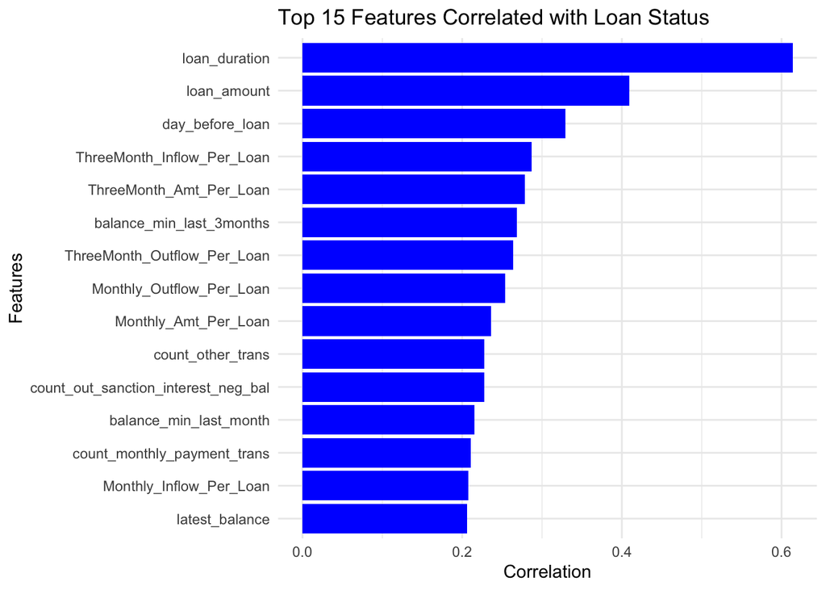

## Step 3: Model Development

### GBM model

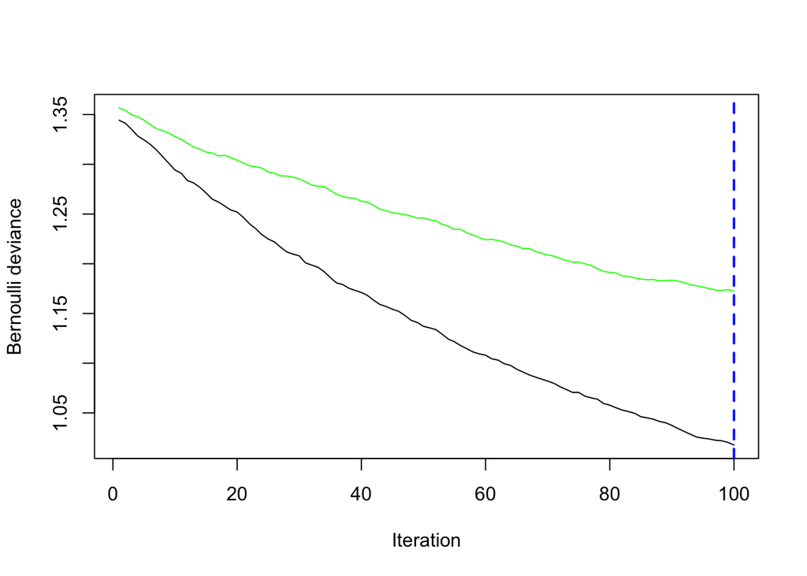

```
Best number of trees based on CV:  100
```

```
         Actual
Predicted  0  1
        0  6  1
        1  3 12
```

```
Accuracy:  0.8181818
```

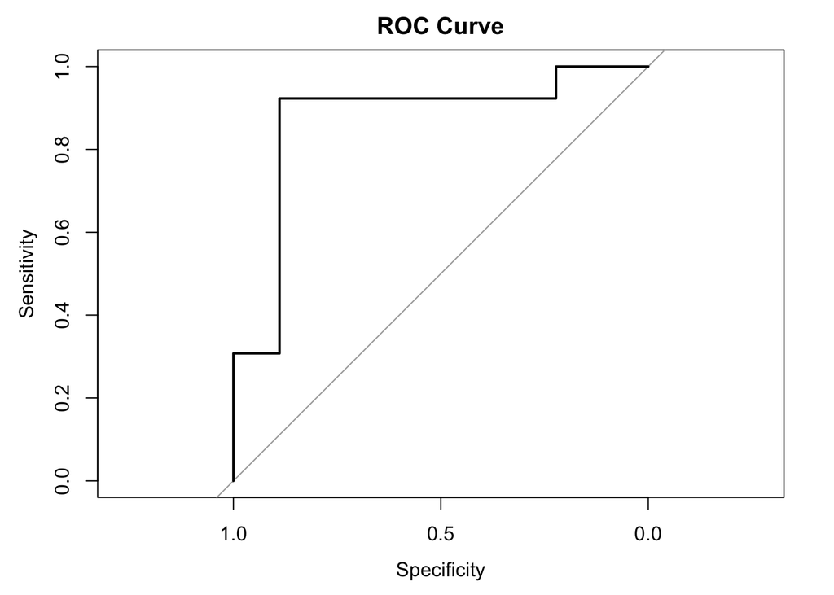

```
AUC:  0.8717949
```

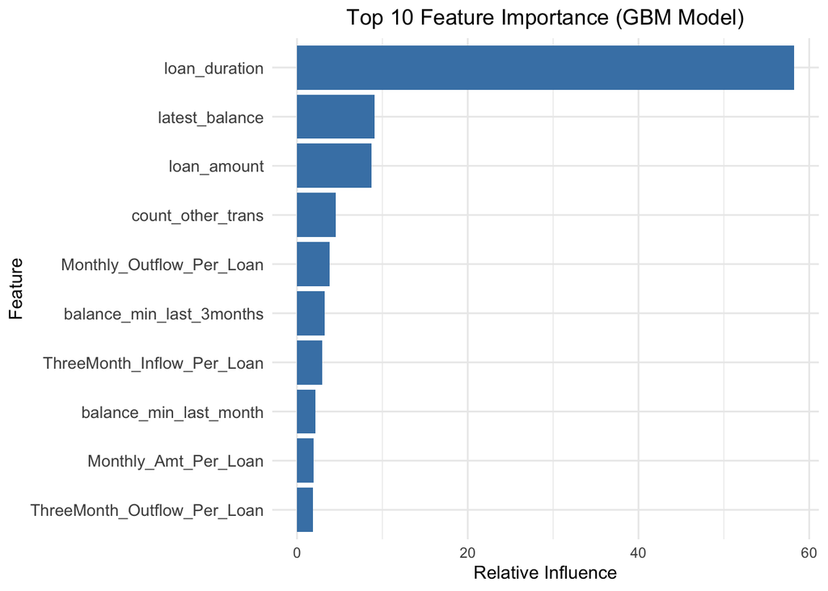

### ROSE

```
  0   1
189 211
```

### GLM with Random Oversampling

```
Call:
glm(formula = loan_status ~ ., family = binomial(link = "logit"),
    data = train_data_rose)

Coefficients:
                                      Estimate Std. Error z value Pr(>|z|)
(Intercept)                         -3.885e+00  5.704e-01  -6.811 9.70e-12 ***
loan_duration                        9.383e-02  1.142e-02   8.215  < 2e-16 ***
loan_amount                          2.052e-06  1.266e-06   1.621 0.104961
day_before_loan                      3.663e-03  9.879e-04   3.708 0.000209 ***
ThreeMonth_Inflow_Per_Loan          -7.734e-01  5.012e-01  -1.543 0.122823
ThreeMonth_Amt_Per_Loan             -3.428e-01  2.216e-01  -1.547 0.121793
balance_min_last_3months            -9.198e-06  1.174e-05  -0.783 0.433510
ThreeMonth_Outflow_Per_Loan          1.227e+00  4.973e-01   2.468 0.013590 *
Monthly_Outflow_Per_Loan            -3.637e-01  4.751e-01  -0.766 0.443960
Monthly_Amt_Per_Loan                -4.028e-02  2.715e-01  -0.148 0.882056
count_other_trans                   -1.651e-03  6.085e-03  -0.271 0.786175
count_out_sanction_interest_neg_bal  3.996e-01  9.761e-02   4.094 4.23e-05 ***
balance_min_last_month              -7.905e-06  9.223e-06  -0.857 0.391400
count_monthly_payment_trans         -3.001e-02  8.499e-03  -3.530 0.000415 ***
Monthly_Inflow_Per_Loan              1.029e+00  4.859e-01   2.118 0.034216 *
latest_balance                      -6.454e-06  5.300e-06  -1.218 0.223293
---
Signif. codes:  0 '***' 0.001 '**' 0.01 '*' 0.05 '.' 0.1 ' ' 1

(Dispersion parameter for binomial family taken to be 1)

    Null deviance: 553.31  on 399  degrees of freedom
Residual deviance: 315.17  on 384  degrees of freedom
AIC: 347.17

Number of Fisher Scoring iterations: 5
```

```
Confusion Matrix:
```

```
         Actual
Predicted  0  1
        0  7  1
        1  2 12
```

```
Accuracy:  0.8636364
```

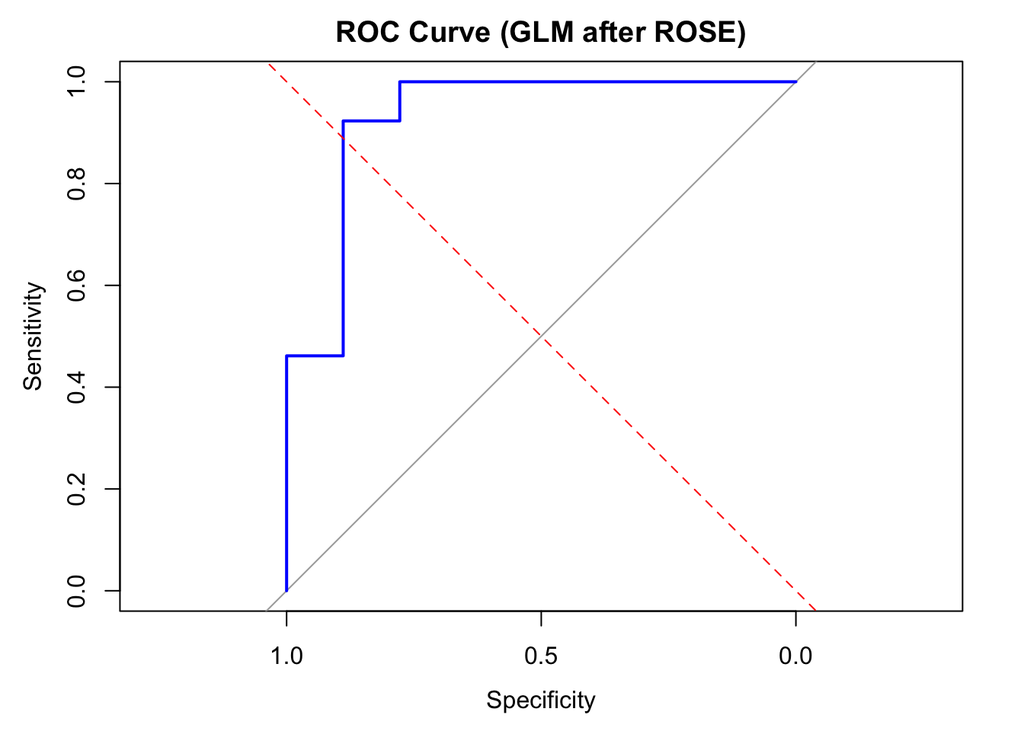

```
AUC:  0.9316239
```

####Naive bayes with Random Oversampling

```
Confusion Matrix:
```

```
         Actual
Predicted  0  1
        0  2  1
        1  7 12
```

```
Accuracy:  0.6363636
```

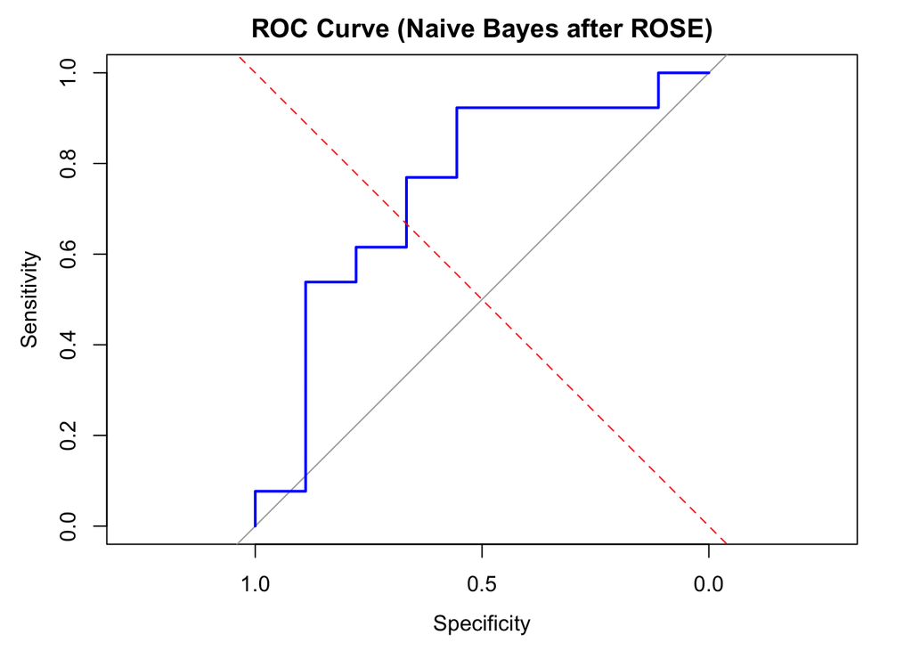

```
AUC:  0.7435897
```

### Random forest with Random Oversampling

```
Call:
 randomForest(formula = loan_status ~ ., data = train_data_rose,      ntree = 100, mtry = 3, importance = TRUE)
               Type of random forest: classification
                     Number of trees: 100
No. of variables tried at each split: 3

        OOB estimate of  error rate: 11.75%
Confusion matrix:
    0   1 class.error
0 169  20   0.1058201
1  27 184   0.1279621
```

```
Confusion Matrix:
```

```
         Actual
Predicted  0  1
        0  3  1
        1  6 12
```

```
Accuracy:  0.6818182
```

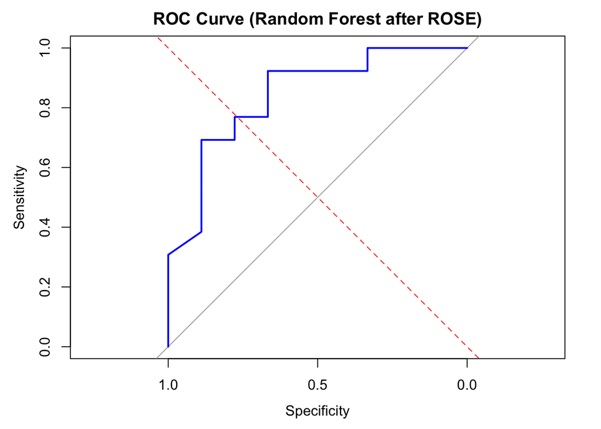

```
AUC:  0.8418803
```

### GLM with grid search

```
Accuracy (GLMNET):  0.8181818
```

```
AUC (GLMNET):  0.8803419
```

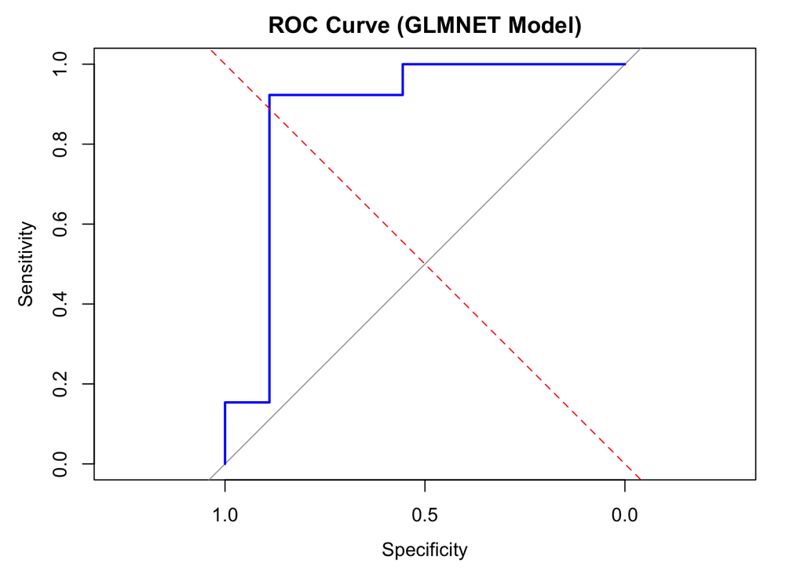

### Model evaluation

Model Performance Comparison

| Model | Accuracy | ROC AUC |
| --- | --- | --- |
| GBM (CV) | 0.818181818181818 | 0.871794871794872 |
| GLM with Random Oversampling | 0.863636363636364 | 0.931623931623932 |
| Naive Bayes with Random Oversampling | 0.636363636363636 | 0.743589743589744 |
| Random Forest with Random Oversampling | 0.681818181818182 | 0.841880341880342 |
| GLMNET (Grid Search) | 0.818181818181818 | 0.88034188034188 |